# Review_VAE

### Jupyter Notebook 단축키

- ctrl+enter: 셀 실행
- shift+enter: 셀 실행 및 다음 셀 이동
- alt+enter: 셀 실행, 다음 셀 이동, 새로운 셀 생성
- a: 상단에 새로운 셀 만들기
- b: 하단에 새로운 셀 만들기
- dd: 셀 삭제(x: 셀 삭제)
- esc: 셀 나가기
- m: 마크다운 셀로 바꾸기
- y: 마크다운 셀을 다시Code로 바꾸기

# *22년 01월 11일 프로그래밍 세미나

** **발표자: 송승환**

## Variational AutoEncoder (VAE) & Adversarial Autoencoder (AAE)

## 1. Variational AutoEncoder (VAE)

### What is VAE?

- VAE는 데이터가 생성되는 과정, 즉 데이터의 확률분포를 학습하기 위한 두 개의 뉴럴네트워크로 구성되어 있음

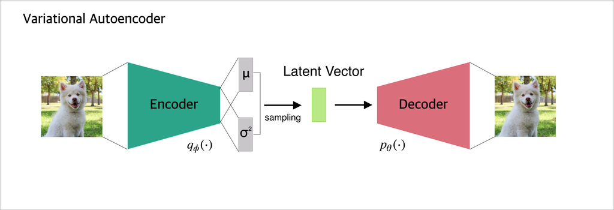

- VAE는 AutoEncoder (AE)와 유사하게 *Encoder* 와 *Decoder* 로 이루어짐
  - *Encoder* : 관측된 데이터 $x$를 입력 받아 잠재변수 $z$를 만드는 역할을 수행
  - *Decoder* : *Encoder* 가 만든 $z$를 활용해 $x$를 복원하는 역할을 수행

### Latent Vector: Part 1

- VAE의 *Decoder* 파트는 다음과 같이 정규분표를 전제로 함
  - 즉 *Encoder* 가 만들어낸 $z$ 의 평균과 분산을 모수로 하는 정규분포를 의미

$$ p(x|z)={N}(x|f_{\mu}(z),f_{\theta}(z)^{(2)}\times I) $$

- 최대우도추정(Maximum Likelihood Estimation, MLE) 방식으로 VAE 모델의 paremeter를 추정하려면 다음과 같이 정의된 marginal log-likelihood $log p(x)$ 를 최대화하면 됨

$$ log p(x)= log \sum_{z} p(x|f_{\mu}(z),f_{\theta}(z)^{(2)}\times I)p(z) $$

- $z$ 는 implicit 하기 때문에, 모든 $z$에 대해 고려가 어려움

-> 따라서 변분추론(Variational Inference)을 사용하고자 함 (Variational Inference: 확률 분포를 다루기 쉬운 분포로 근사하는 방법)

### Latent Vector: Part 2

- **Variational Inference** 를 사용하기 위해 Bayes' theorem의 Evidence of Lower Bound (ELBO)를 이용
  - $q(z)$: 다루기 쉬운 분포
  - $p(x)$: Bayes' theorem 에서의 evidence
- 몇 가지 수식 유도 과정을 거치면 evidence의 ELBO를 다음과 같이 구할 수 있음 (아래 수식의 우변)

$$ log p(x) >= E_{z \sim q(z)}[log p(x|z)] - D_{KL}(q(z)||p(z)) $$

- 즉, ELBO를 최대화하여 $log p(x)$를 최대화할 수 있음

### Latent Vector: Part 3

- 일반적인 Variational Inference 에서 $q(z)$를 정규분포로 정함 $q(z) = N(\mu_{q}, \sigma_{q}^{2})$
- 하지만, 데이터 $x$가 고차원일 때는 $q$를 위와 같이 정하게 되면 학습이 어려운 문제가 존재함
  - 모든 데이터에 대해 동일한 평균과 분산, 즉 단 하나의 정규분포를 가정하기 떄문 (데이터는 복잡하지만, 모델이 단순한 문제)
- 따라서, VAE는 이러한 문제 해결을 위해 $q$의 parameter를 $x$에 대한 함수로 설정함 $$q(z|x) = N(\mu_{q}(x), \scriptstyle \Sigma_{q}\textstyle (x))$$

## - $q$를 위와 같이 설정하고 ELBO를 최대화하는 방향으로 $q$를 잘 학습하면, $x$가 달라질 때마다 $q$의 분포도 계속 달라지게 됨

https://github.com/pytorch/examples/blob/master/vae/main.py

### 1) 모듈 불러오기

```python
# !pip install IPython
# ! pip install easydict
```

```python
''' 기본 모듈 및 시각화 모듈 '''
from __future__ import print_function # Python 2 and 3 혼용
from IPython.display import Image
import easydict #import argparse 대체로 사용

''' PyTorch 사용을 위한 모듈 '''
import torch
import torch.utils.data
from torch import nn, optim
from torch.nn import functional as F
from torchvision import datasets, transforms
from torchvision.utils import save_image
```

### 2) Hyperparameter 설정

```python
args = easydict.EasyDict({
    "batch_size": 128,
    "epochs": 10,
    "no_cuda": False,
    "seed": 1,
    "log_interval": 10
})
```

```python
''' cuda 사용 '''
args.cuda = not args.no_cuda and torch.cuda.is_available()
torch.manual_seed(args.seed)

device = torch.device("cuda" if args.cuda else "cpu")
```

### 3) Data Load

```python
kwargs = {'num_workers': 1, 'pin_memory': True} if args.cuda else {}
train_loader = torch.utils.data.DataLoader(
    datasets.MNIST('../data', train=True, download=True,
                   transform=transforms.ToTensor()),
    batch_size=args.batch_size, shuffle=True, **kwargs)
test_loader = torch.utils.data.DataLoader(
    datasets.MNIST('../data', train=False, transform=transforms.ToTensor()),
    batch_size=args.batch_size, shuffle=True, **kwargs)
```

### 4) VAE Architecture

## - VAE의 *Encoder* 에는, $x$를 입력받아 $z$의 평균과 분산을 만들어내는 뉴럴네트워크가 두 개 $(f_{\mu}, f_{\sigma})$가 포함되어 있으므로 복잡한 데이터에 대해서도 모델이 잘 적응할 수 있음

### Reparameterization Trick

- 노이즈를 *zero-mean Gaussian* 에서 샘플링하고 $(f_{\mu}, f_{\sigma})$가 산출한 평균과 분산을 더하고 곱해줘서 **sampled latent vector** $z$를 만드는 과정

$$ z = \mu(x) + \sigma(x) \times \epsilon, \epsilon \sim N(0,1) $$

```python
class VAE(nn.Module):

    ''' 28X28 이미지를 일자로 펴서 784 크기의 vector로 만듦 '''
    def __init__(self):
        super(VAE, self).__init__()

        self.fc1 = nn.Linear(784, 400)
        self.fc21 = nn.Linear(400, 20)
        self.fc22 = nn.Linear(400, 20)
        self.fc3 = nn.Linear(20, 400)
        self.fc4 = nn.Linear(400, 784)

    '''
    Encoder: 784-D vector가 input으로 들어와서 400-D hidden layer를 통과 (relu)
    이후 20개의 gaussian 분포에 대한 mean과 variance를 내보냄
    '''
    def encode(self, x):
        h1 = F.relu(self.fc1(x))
        return self.fc21(h1), self.fc22(h1) # Mean: self.fc21(h1) # Var: self.fc22(h1)
    '''
    Variance의 경우 항상 0보다 크거나 같아야하는데, linear 연산을 한 self.fc22(h1)의 경우 -값이 될 수 있음
    따라서 이 값을 variance로 보지 않고 log variance(logvar)로 사용
    '''


    '''
    Reparameterization Trick: latent space 상에서의 mean과 log variance를 구했다면,
    reparameterization을 통해 latent vector를 sampling 수행
    '''
    def reparameterize(self, mu, logvar):
        std = torch.exp(0.5*logvar)
        eps = torch.randn_like(std)
        return mu + eps*std


    '''
    Decoder: latent 값으로부터 data에 대한 Bernoulli distribution을 출력
    Bernoulli 분포는 0에서 1 사이이므로 sigmoid 함수를 output layer의 activation function으로 사용
    '''
    def decode(self, z):
        h3 = F.relu(self.fc3(z))
        return torch.sigmoid(self.fc4(h3))

    def forward(self, x):
        mu, logvar = self.encode(x.view(-1, 784)) # x.view(-1, 784): 이미지를 784-D vector로 만드는 부분
        z = self.reparameterize(mu, logvar)
        return self.decode(z), mu, logvar
```

### 모델 및 손실 함수, Optimizer 설정

#### * Step1. KLD 변형식 유도

$ D_{KL}(q(z)||p(z|x))=D_{KL}(q(z)||p(z))+logp(x)−E_{z \sim q(z)}[logp(x|z)] $

#### * Step2. 정규분포 $q$를 이용

$ logp(x)=E_{z \sim q(z|x)}[logp(x|z)]-D_{KL}(q(z|x)||p(z))+D_{KL}(q(z|x)||p(z|x))$

= *ELBO* $+ D_{KL}(q(z|x)||p(z|x)) $

#### * Step3. 동일한 확률변수에 대한 KLD 값(위 식 우변 세번째 항)은 항상 양수이므로 아래와 같은 부등식이 항상 성립

$ logp(x)>=E_{z \sim q(z|x)}[logp(x|z)]-D_{KL}(q(z|x)||p(z)) $ = *ELBO*

#### * Step4. 정리

- 위 부등식 우변, 즉 ELBO를 최대화하면 marginal log-likelihood $logp(x)$를 최대화할 수 있게 됨
- 또한, ELBO를 최대화한다는 것은 $q(z|x)$와 $p(z|x)$ 사이의 KLD를 최소화하는 의미로 해석할 수 있음
- 따라서, **Step3** 부등식의 우변에 음수를 곱한 식이 loss function이 되고, 이 함수를 최소화하는 것이 VAE의 학습 목표가 됨

### 손실 함수

$ L=−E_{z \sim q(z|x)}[logp(x|z)]+D_{KL}(q(z|x)||p(z)) $

- 첫번째 항: *reconstruction loss* , *Encoder* 가 데이터 $x$를 입력 받아 $q$로부터 $z$를 추출하고 *Decoder* 는 *Encoder* 가 만든 $z$를 입력 받아 원 데이터 $x$를 복원하므로, 첫번째 항은 이 둘 사이의 크로스 엔트로피(binary cross entropy)를 의미함
- 두번째 항: *KL Divergence Regularizer* , VAE는 $z$가 zero-mean Gaussian이라고 가정하므로 계산이 간단하게 유도됨
  - $ D_{KL}(q(z|x)||p(z)) = \frac{1} {2} \sum_{i=1} (\sigma_{i}^{2}+\mu_{i}^{2}-ln(\sigma_{i}^{2})-1)$
  - 이는 $q$를 zero-mean Gaussian에 가깝게 만드는 것을 의미함

```python
model = VAE().to(device)
optimizer = optim.Adam(model.parameters(), lr=1e-3)
```

### 5) Train VAE

```python
# Reconstruction + KL divergence losses summed over all elements and batch
def loss_function(recon_x, x, mu, logvar):
    BCE = F.binary_cross_entropy(recon_x, x.view(-1, 784), reduction='sum')


    KLD = -0.5 * torch.sum(1 + logvar - mu.pow(2) - logvar.exp())
    # 0.5 * sum(1 + log(sigma^2) - mu^2 - sigma^2)

    return BCE + KLD
```

```python
def train(epoch):
    model.train()
    train_loss = 0

    ''' train_loader를 통해 mini_batch를 추출 '''
    for batch_idx, (data, _) in enumerate(train_loader):
        data = data.to(device)
        optimizer.zero_grad()
        recon_batch, mu, logvar = model(data)
        loss = loss_function(recon_batch, data, mu, logvar)
        ''' loss.backward()를 통해 back-propagation으로 각 parameter의 gradient 값을 구함 '''
        loss.backward()
        train_loss += loss.item()
        optimizer.step()
        if batch_idx % args.log_interval == 0:
            print('Train Epoch: {} [{}/{} ({:.0f}%)]\tLoss: {:.6f}'.format(
                epoch, batch_idx * len(data), len(train_loader.dataset),
                100. * batch_idx / len(train_loader),
                loss.item() / len(data)))

    print('====> Epoch: {} Average loss: {:.4f}'.format(
          epoch, train_loss / len(train_loader.dataset)))
```

### 6) Evaluate VAE

```python
def test(epoch):
    model.eval()
    test_loss = 0
    with torch.no_grad():
        for i, (data, _) in enumerate(test_loader):
            data = data.to(device)
            recon_batch, mu, logvar = model(data)
            test_loss += loss_function(recon_batch, data, mu, logvar).item()
            if i == 0:
                n = min(data.size(0), 8)
                comparison = torch.cat([data[:n],
                                      recon_batch.view(args.batch_size, 1, 28, 28)[:n]])
                ''' 각 evaluation 과정마다 생성된 하나의 sample을 저장 '''
                save_image(comparison.cpu(),
                         'results_VAE_10/reconstruction_' + str(epoch) + '.png', nrow=n)

    test_loss /= len(test_loader.dataset)
    print('====> Test set loss: {:.4f}'.format(test_loss))
```

### 7) Main Loop

```python
''' Epoch마다 train을 하고 test를 한 다음에 64개의 sample 이미지를 생성 '''
''' Latent는 임의로 20개를 normal distribution에서 sampling '''
if __name__ == "__main__":
    for epoch in range(1, args.epochs + 1):
        train(epoch)
        test(epoch)
        with torch.no_grad():
            sample = torch.randn(64, 20).to(device)
            sample = model.decode(sample).cpu()
            ''' Sampling된 latent variable을 Decoder에 통과시키면 Decoder는 이미지를 생성 후 저장 '''
            save_image(sample.view(64, 1, 28, 28),
                       'results_VAE_10/sample_' + str(epoch) + '.png')
```

```
Train Epoch: 1 [0/60000 (0%)]	Loss: 126.190361
Train Epoch: 1 [1280/60000 (2%)]	Loss: 128.627625
Train Epoch: 1 [2560/60000 (4%)]	Loss: 128.485809
Train Epoch: 1 [3840/60000 (6%)]	Loss: 121.148689
Train Epoch: 1 [5120/60000 (9%)]	Loss: 123.168930
Train Epoch: 1 [6400/60000 (11%)]	Loss: 126.847107
Train Epoch: 1 [7680/60000 (13%)]	Loss: 130.177338
Train Epoch: 1 [8960/60000 (15%)]	Loss: 126.319229
Train Epoch: 1 [10240/60000 (17%)]	Loss: 126.570175
Train Epoch: 1 [11520/60000 (19%)]	Loss: 127.205246
Train Epoch: 1 [12800/60000 (21%)]	Loss: 129.055786
Train Epoch: 1 [14080/60000 (23%)]	Loss: 118.832230
Train Epoch: 1 [15360/60000 (26%)]	Loss: 122.987946
Train Epoch: 1 [16640/60000 (28%)]	Loss: 120.330261
Train Epoch: 1 [17920/60000 (30%)]	Loss: 123.583633
Train Epoch: 1 [19200/60000 (32%)]	Loss: 118.344971
Train Epoch: 1 [20480/60000 (34%)]	Loss: 117.626511
Train Epoch: 1 [21760/60000 (36%)]	Loss: 124.706604
Train Epoch: 1 [23040/60000 (38%)]	Loss: 122.467392
Train Epoch: 1 [24320/60000 (41%)]	Loss: 122.978401
Train Epoch: 1 [25600/60000 (43%)]	Loss: 121.517853
Train Epoch: 1 [26880/60000 (45%)]	Loss: 122.564728
Train Epoch: 1 [28160/60000 (47%)]	Loss: 124.690758
Train Epoch: 1 [29440/60000 (49%)]	Loss: 121.755318
Train Epoch: 1 [30720/60000 (51%)]	Loss: 123.477364
Train Epoch: 1 [32000/60000 (53%)]	Loss: 117.051804
Train Epoch: 1 [33280/60000 (55%)]	Loss: 122.634979
Train Epoch: 1 [34560/60000 (58%)]	Loss: 119.540817
Train Epoch: 1 [35840/60000 (60%)]	Loss: 116.774368
Train Epoch: 1 [37120/60000 (62%)]	Loss: 116.849121
Train Epoch: 1 [38400/60000 (64%)]	Loss: 119.366699
Train Epoch: 1 [39680/60000 (66%)]	Loss: 124.924454
Train Epoch: 1 [40960/60000 (68%)]	Loss: 118.709183
Train Epoch: 1 [42240/60000 (70%)]	Loss: 120.379967
Train Epoch: 1 [43520/60000 (72%)]	Loss: 116.785805
Train Epoch: 1 [44800/60000 (75%)]	Loss: 121.685486
Train Epoch: 1 [46080/60000 (77%)]	Loss: 115.078369
Train Epoch: 1 [47360/60000 (79%)]	Loss: 116.247955
Train Epoch: 1 [48640/60000 (81%)]	Loss: 123.859436
Train Epoch: 1 [49920/60000 (83%)]	Loss: 118.557510
```

[output cut: 435 more lines]

```
Train Epoch: 10 [43520/60000 (72%)]	Loss: 108.208824
Train Epoch: 10 [44800/60000 (75%)]	Loss: 102.652100
Train Epoch: 10 [46080/60000 (77%)]	Loss: 107.011871
Train Epoch: 10 [47360/60000 (79%)]	Loss: 106.915405
Train Epoch: 10 [48640/60000 (81%)]	Loss: 106.337608
Train Epoch: 10 [49920/60000 (83%)]	Loss: 105.226669
Train Epoch: 10 [51200/60000 (85%)]	Loss: 102.234383
Train Epoch: 10 [52480/60000 (87%)]	Loss: 105.954170
Train Epoch: 10 [53760/60000 (90%)]	Loss: 107.072693
Train Epoch: 10 [55040/60000 (92%)]	Loss: 103.754204
Train Epoch: 10 [56320/60000 (94%)]	Loss: 108.693375
Train Epoch: 10 [57600/60000 (96%)]	Loss: 107.679794
Train Epoch: 10 [58880/60000 (98%)]	Loss: 108.692734
====> Epoch: 10 Average loss: 105.8186
====> Test set loss: 105.3210
```